# PSTAT 131 Final Project

Finn Stack

2022-06-01

# Introduction

The purpose of this final project is to calculate the number of ascents an outdoor rock climb will receive based off of the difficulty (grade), location, type of climb, and it’s star rating.

The goal of outdoor rock climbing is to get up a rock or cliff face taking the most difficult path you’re able to do. For the purpose of this project, I will call the path that someone takes to get up a rock or cliff face a climb. The difficulty of a route varies among everyone because of varying levels of skill, experience, and strength. While there isn’t one specific criteria that makes one route harder than another, there are some factors that usually contribute to the difficulty and grade of the climb. These factors are mainly hold size, distance between holds, steepness of the rock, and length of the climb. Some climbs will have holds that are as small as 4mm, while others you can fit you whole hand on. There are times where you completely have to jump between the holds and have all four limbs leave the rock. Some routes will be completely vertical while others can be practically horizontal. Some routes will be 50 meters long, while others are only a few meters.

In this analysis, I will be addressing two types of climbing: Bouldering and Lead Climbing. Bouldering consists of shorter routes and you place crash pads to fall on. There is no rope or other equipment used. Lead climbing consists of much longer routes, where you need a rope to secure your safety.

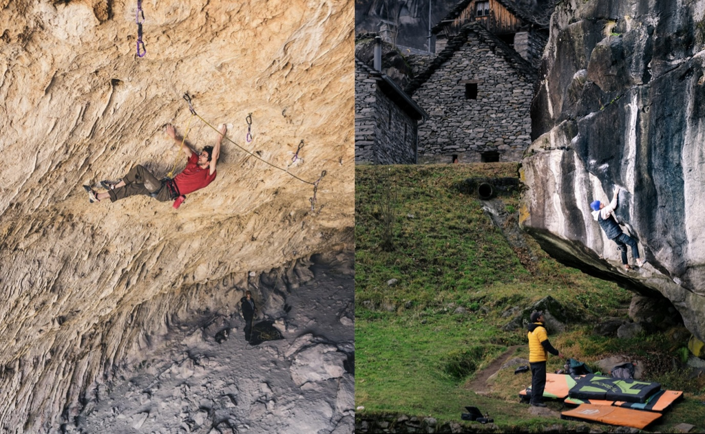

Lead vs. Bouldering

Each of these disciplines also has their own grading system for difficulty. The grading system for climbing is depicted as follows. From easiest to hardest: 6a, 6a+, 6b, 6b+, 6c, …, 9a+, 9b, 9b+, 9c

However, the Bouldering grade scale only goes up to 9a, while the lead scale goes up to 9c. This doesn’t mean that one’s harder than the other. There’s just a slightly different scale for the two disciplines of rock climbing.

Naturally, more people are able to do easier routes. Only a few people in the world have been able to climb 9a in Bouldering or 9c in Lead Climbing.

# Why might this data be useful

Having data on the amount of ascents a climb will receive that is being established for the first time could help areas understand how much traffic it will recieve as well as the impact on the nature around it.

# Loading data and packages

For my analysis, I am using data collected from *[8a.nu](https://www.8a.nu/crags/sportclimbing)*, a website where climbers all over the world can log their ascents. I have collected data from the most popular Bouldering and Lead areas.

Areas: Magic Wood (Switzerland), Buttermilks (California), Rodellar (Spain), Ceuse (France), Chironico (Switzerland), Cuenca (Spain)

Key variables in the data:

- `Climb` = the name of the route given by the person to complete the first ascent. Doesn’t play a role in my analysis
- `Ascents` = the number of a ascents a route has received
- `Grade` = the difficulty of the climb rated on the system described above
- `Location` = what crag the climb is located in around the world
- `Type` = signifies whether it is Bouldering (B) or Lead (L). This data was manipulated to be numeric
- `Star Rating` = the rating the climb has received from the community. Ranked from 1 (lowest) to 5 (highest)

```r
# Reading the data

climb_ascents <- read_csv("/Users/finnianstack/Desktop/School/PSTAT/PSTAT 131/Final Project/8a.nu Climbs.csv")

crag_summary <- read_csv("/Users/finnianstack/Desktop/School/PSTAT/PSTAT 131/Final Project/CRAGS SUMMARY.csv")

ascents_numerical <- read_csv("/Users/finnianstack/Desktop/School/PSTAT/PSTAT 131/Final Project/8a.nu Climbs.csv")

ascents_factor <-read_csv("/Users/finnianstack/Desktop/School/PSTAT/PSTAT 131/Final Project/8a.nu Climbs.csv")
```

# Data Cleaning

```r
climb_ascents <- climb_ascents %>%
  clean_names()

ascents_numerical <- ascents_numerical%>%
  clean_names()

ascents_factor <- ascents_factor %>%
  clean_names()
```

I removed the variable `climb` which is the climb name from our data set because it isn’t going to play a role in our analysis

```r
climb_ascents <- climb_ascents %>%
 select(-climb)

ascents_numerical <- ascents_numerical %>%
 select(-climb)

ascents_factor <- ascents_factor %>%
 select(-climb)
```

Then, I turned the `type_b_l` variable into 1 = Bouldering and 0 = Lead

```r
climb_ascents$type_b_l <- ifelse(climb_ascents$type_b_l == "B", 1, 0)

ascents_numerical$type_b_l <- ifelse(ascents_numerical$type_b_l == "B", 1, 0)
```

I also made all of the variables in my ascents_numerical dataset all numerical values.

```r
ascents_numerical$grade <- as.factor(ascents_numerical$grade)
ascents_numerical$grade <- as.integer(ascents_numerical$grade)

ascents_numerical$location <- as.factor(ascents_numerical$location)
ascents_numerical$location <- as.numeric(ascents_numerical$location)
```

The final alteration I made while cleaning the data was making a dataset of all the variables as factors.

```r
ascents_factor$grade <- as.factor(ascents_factor$grade)
ascents_factor$location <- as.factor(ascents_factor$location)
ascents_factor$ascents <- as.factor(ascents_factor$ascents)
ascents_factor$type_b_l <- as.factor(ascents_factor$type_b_l)
ascents_factor$star_rating <- as.factor(ascents_factor$star_rating)
```

# Data Split

```r
ascents_split <- climb_ascents %>%
  initial_split(prop = 0.8, strata = "ascents")

ascents_train <- training(ascents_split)
ascents_test <- testing(ascents_split)


ascents_split_numerical <- ascents_numerical %>%
  initial_split(prop = 0.8, strata = "ascents")

ascents_train_numerical <- training(ascents_split_numerical)
ascents_test_numerical <- testing(ascents_split_numerical)

ascents_split_factor <- ascents_factor %>%
  initial_split(prop = 0.8, strata = "ascents")

ascents_train_factor <- training(ascents_split_factor)
ascents_test_factor <- testing(ascents_split_factor)
```

# Exploratory Data Analysis

It appears that the data somewhat resembles a normal distribution, except the grade 7A appears to be a bit of an outlier. From experience, I would say that there are in general more easy climbs, but the those who climb easier grades generally don’t log their ascents in 8a.nu. If we put aside the fact that many people don’t log their easier ascents, there is a clear downward trend as the difficulty increases.

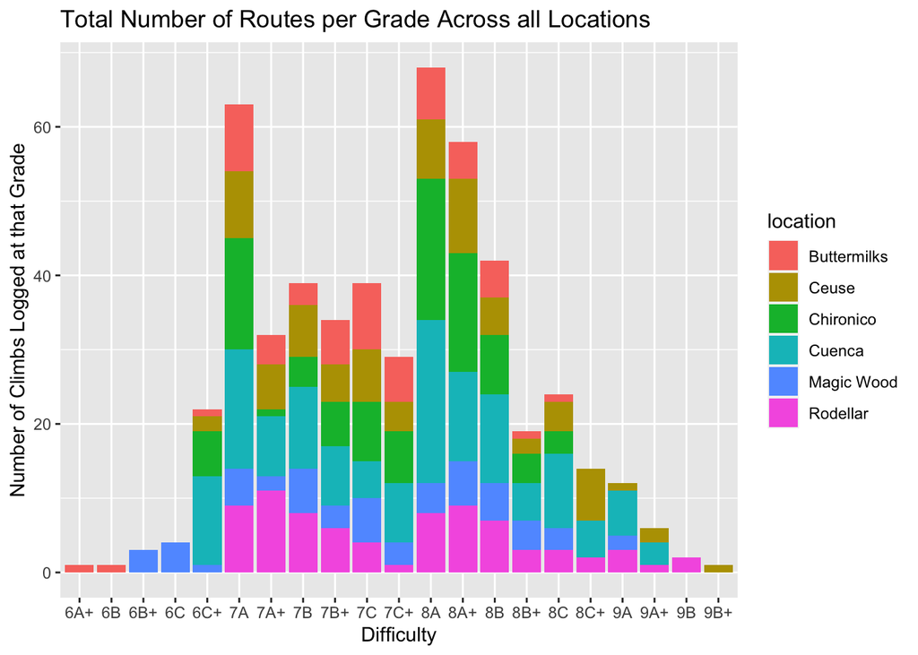

```r
ggplot(climb_ascents, aes(fill = location, x = grade)) +
  geom_bar() +
  labs(
    title = "Total Number of Routes per Grade Across all Locations",
    x = "Difficulty",
    y = "Number of Climbs Logged at that Grade")
```

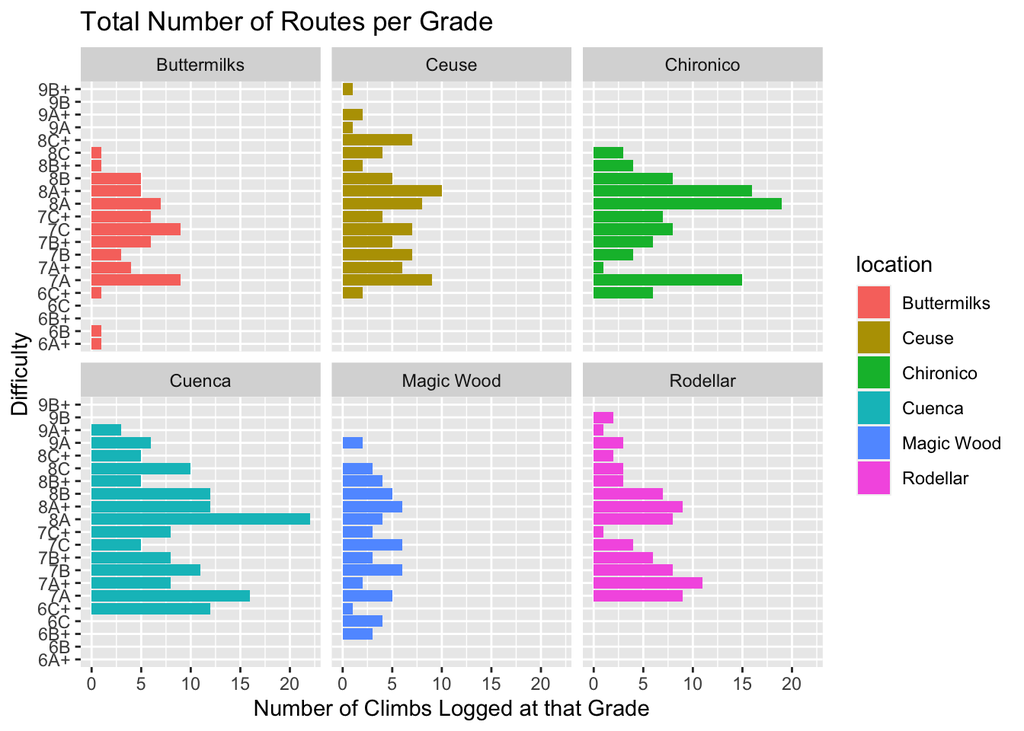

```r
ggplot(climb_ascents, aes(fill = location, y = grade)) +
  geom_bar() +
  facet_wrap(~location) +
  labs(
    title = "Total Number of Routes per Grade",
    y = "Difficulty",
    x = "Number of Climbs Logged at that Grade")
```

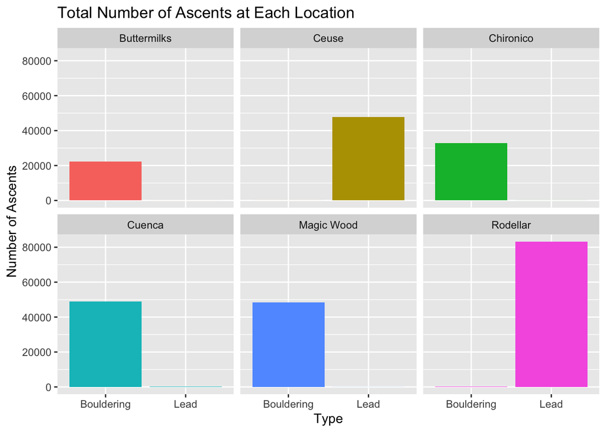

```r
ggplot(crag_summary, aes(fill = Crag, y = Ascents, x = Type)) +
    geom_bar(position="dodge", stat="identity") +
    ggtitle("Total Number of Ascents at Each Location") +
    facet_wrap(~Crag) +
    theme(legend.position = "none") +
    xlab("Type") +
  ylab("Number of Ascents")
```

From these barplots, we can see that each area is really known for either Bouldering or Lead. Not both. Thus, where a climb is located and the type of climbing, should play a large role. We can also clearly see that `Rodellar` has by far the most ascents across all grades.

Looking at the barplots separated by location, it is much clearer that there is a negative correlation between the number of ascents and the grade of the route.

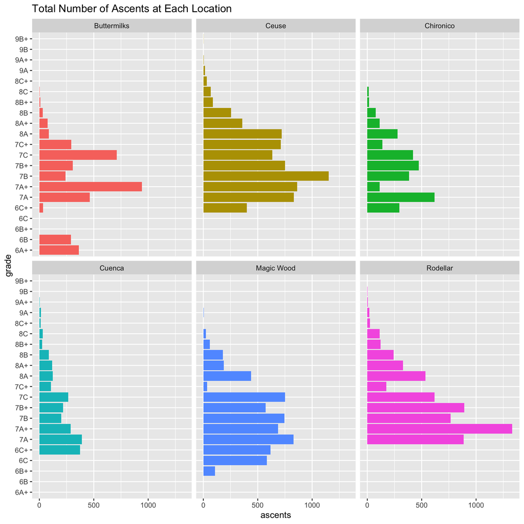

```r
ggplot(climb_ascents, aes(fill = location, y = grade, x = ascents)) +
    geom_bar(position = "dodge", stat="identity") +
    ggtitle("Total Number of Ascents at Each Location") +
    facet_wrap(~location) +
    theme(legend.position="none")
```

It appears that in all locations, more routes than any other have a 4 star rating, while very few have a 5 star rating.

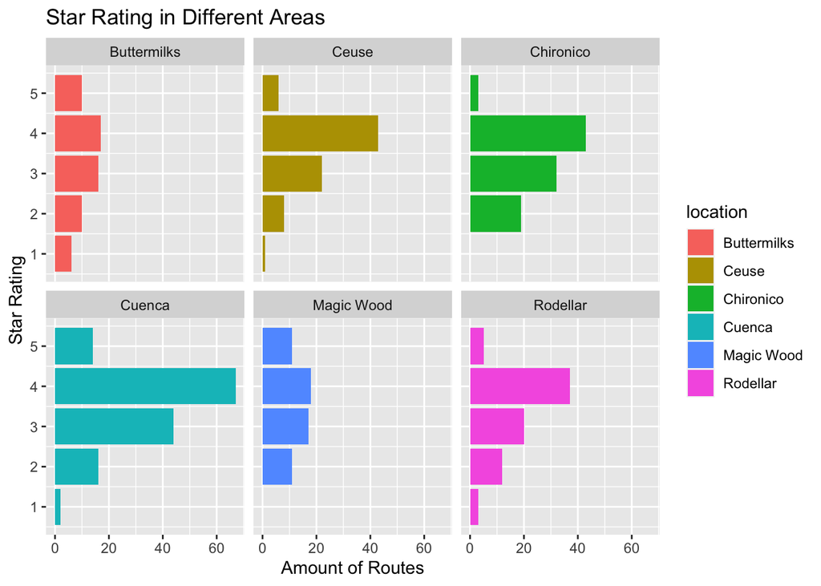

```r
ggplot(climb_ascents, aes(fill = location, y = star_rating)) +
  geom_bar() +
  facet_wrap(~location) +
  labs(
    title = "Star Rating in Different Areas",
    y = "Star Rating",
    x = "Amount of Routes")
```

It’s interesting to note how at more difficult grades, the median of the star rating is higher. I think this could be explained by the fact that since there are so few people who can climb the higher grades, when they choose to establish a route for the first time, they perceive it as a really good one. Also, since the star rating is based off of the average of all the people who have ascended it, there are far fewer people to rate it when the climb is very difficult.

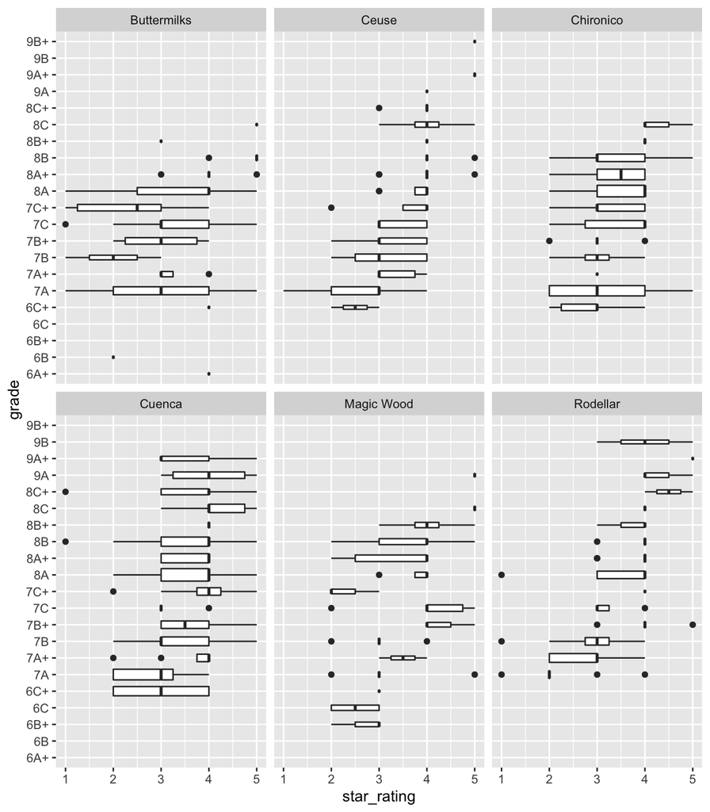

```r
ggplot(climb_ascents, aes(grade, star_rating)) +
  geom_boxplot(varwidth = TRUE) +
  facet_wrap(~location) +
  coord_flip()
```

Converting the `grade` and `location` variables to nominal variables will allow us to analyze a correlation matrix. To do this, I used a fresh dataset (not the training or test data set because I don’t need to change all of the variables to numeric for later analysis) and converted the variables to factors and then integers. This allowed for a complete correlation matrix with all the variables.

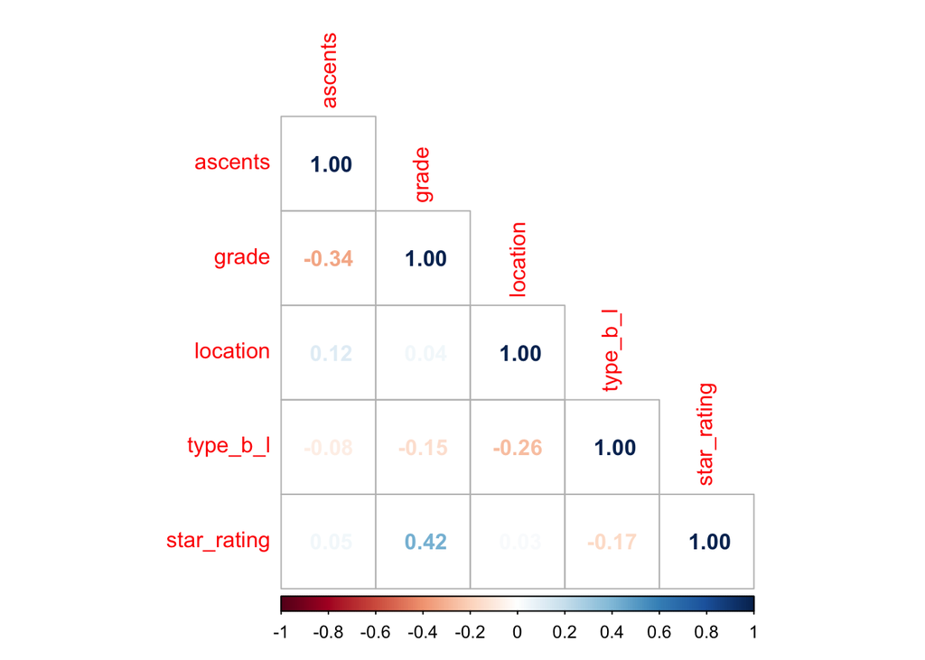

```r
ascents_numerical %>%
  select(where(is.numeric)) %>%
  cor(use = "complete.obs") %>%
  corrplot(method = "number", type = "lower")
```

From this, we can see that there is negligible correlation between the `type` of route it is (Bouldering or Lead) or `location` and the other variables. There is, however, a pretty good positive correlation between the `grade` of the climb and `star rating`. We can also see that there is a relatively inverse correlation between the amount of `ascents` and the `grade`, which is to be expected.

# Model Building

First, I will fold the data using vfold_csv. There will be 10 folds with 5 repeats, stratifying around ascents.

```r
ascents_fold <- vfold_cv(ascents_train, v = 10, repeats = 5, strata = ascents)

ascents_fold_numerical <- vfold_cv(ascents_train_numerical, v = 10, repeats = 5, strata = ascents)
```

```r
ascents_fold_factor <- vfold_cv(ascents_train_factor, v = 10, repeats = 5, strata = ascents)
```

Next, I will create a recipe with all of the variables. There will be 4 predictors `grade`, `location`, `type`, and `star rating`) with one outcome (`ascents`). Because of the nature of my dataset, I had to create a couple recipes. One being a recipe for all numerical values in the dataset. The other is a recipe for all factor values in the dataset. Having multiple recipes will come in handy when creating different regression models that require different `type` of variables.

```r
ascents_recipe <- recipe(ascents ~ grade + location + type_b_l + star_rating,
                         data = ascents_train) %>%
  step_dummy(all_predictors()) %>%
  step_zv(all_predictors()) %>%
  step_novel(all_nominal_predictors()) %>%
  step_center(all_predictors()) %>%
  step_scale(all_predictors())

ascents_recipe_numerical <- recipe(ascents ~ grade + location + type_b_l + star_rating,
                         data = ascents_train_numerical) %>%
  step_dummy(all_nominal_predictors()) %>%
  step_zv(all_predictors()) %>%
  step_novel(all_nominal_predictors()) %>%
  step_center(all_predictors()) %>%
  step_scale(all_predictors())

ascents_recipe_factor <- recipe(ascents ~ grade + location + type_b_l + star_rating,
                         data = ascents_train_factor) %>%
  step_dummy(all_nominal_predictors()) %>%
  step_zv(all_predictors()) %>%
  step_novel(all_nominal_predictors()) %>%
  step_center(all_predictors()) %>%
  step_scale(all_predictors())
```

## Ridge Regression

First, I will analyze a ridge regression and see how accurate it is in predicting the amount of ascents a climb will receive. To do this, I will utilize the numerical version of my dataset. To create this model, I will use the `glmnet` engine and the tune the penalty variable by setting it equal to `tune()`.

Here, I created the model and fit the regression to the entire training set.

```r
ridge_spec <- linear_reg(mixture = 0, penalty = tune()) %>%
  set_mode("regression") %>%
  set_engine("glmnet")
```

In this model, I used `grid_regular` which allows me to create a grid of evenly spaced parameter values. From this, I will be able to see the optimal penalty value.

```r
ridge_workflow <- workflow() %>%
  add_recipe(ascents_recipe_numerical) %>%
  add_model(ridge_spec)

penalty_grid <- grid_regular(penalty(range = c(-5, 5)), levels = 50)
penalty_grid

tune_res <- tune_grid(
  ridge_workflow,
  resamples = ascents_fold_numerical,
  grid = penalty_grid
)
```

By using `autoplot()`, we are able to see a visualization of the `rmse` and `rsq` and the amount of regularization.

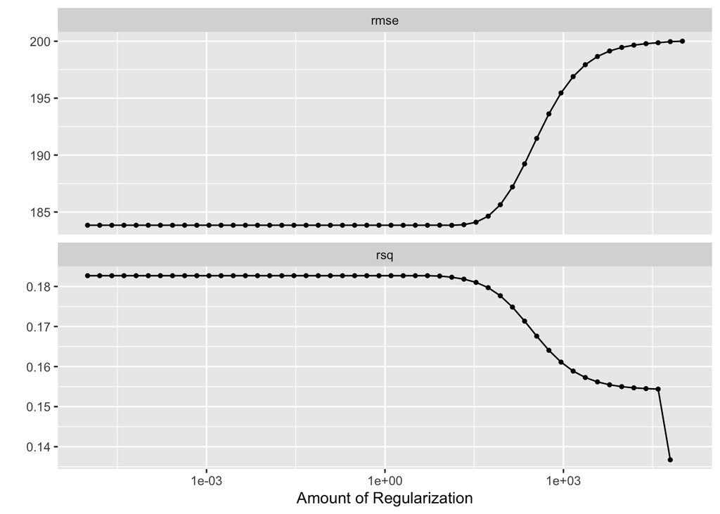

```r
autoplot(tune_res)
```

By using the `select_best()` function we are able to see that the best penalty for this model is $1e^{-5}$

```r
best_penalty <- select_best(tune_res, metric = "rsq")
best_penalty
```

```
## # A tibble: 1 × 2
##   penalty .config
##     <dbl> <chr>
## 1 0.00001 Preprocessor1_Model01
```

```r
ridge_final <- finalize_workflow(ridge_workflow, best_penalty)

ridge_final_fit <- fit(ridge_final, data = ascents_train_numerical)
```

By using `augment` and the test data, I am able to calculate the best estimate for this model which we can see below

```r
ridge_metric <- augment(ridge_final_fit, new_data = ascents_test_numerical) %>%
  rmse(truth = ascents, estimate = .pred)
ridge_metric
```

```
## # A tibble: 1 × 3
##   .metric .estimator .estimate
##   <chr>   <chr>          <dbl>
## 1 rmse    standard        165.
```

## Log Regression

For the log regression model, I will be using the factor recipe I created above. To create this model, I used `logistic_reg()` and set the engine to `glm` and the mode to `classification`.

```r
log_reg <- logistic_reg() %>%
  set_engine("glm") %>%
  set_mode("classification")
```

After creating the `workflow()` function, I am able to fit the function to get the accuracy of this model.

```r
log_wkflow <- workflow() %>%
  add_model(log_reg) %>%
  add_recipe(ascents_recipe_factor)

log_fit <- fit(log_wkflow, ascents_train_factor)
```

By using the `accuracy` function and setting the `truth = ascents`, we are able to see the accuracy of this model is about 3.4% which is quite low.

```r
log_reg_acc <- augment(log_fit, new_data = ascents_train_factor) %>%
  accuracy(truth = ascents, estimate = .pred_class)
log_reg_acc
```

```
## # A tibble: 1 × 3
##   .metric  .estimator .estimate
##   <chr>    <chr>          <dbl>
## 1 accuracy multiclass    0.0341
```

## Lasso Regression

For the Lasso Regression, I am using my numerical data set and numerical recipe. To create the model I used `linear_reg()` and set `mixture = 1` in order to specify to the function that it’s a Lasso model. Within the model, I used `glmnet` and set `penatly = tune()` which tells the model the `penalty` parameter must be tuned. This will allow us to determine the optimal `penalty` value fitting it to the folds.

The first step was fitting the model to the training set. Then, by using `grid_regular` I was able to set up a plot similar to the one created in the ridge model. This will allow us to visualize the `rmse` and `rsq` values against varrying amount of regularization.

```r
lasso_spec <-
  linear_reg(penalty = tune(), mixture = 1) %>%
  set_mode("regression") %>%
  set_engine("glmnet")

lasso_workflow <- workflow() %>%
  add_recipe(ascents_recipe_numerical) %>%
  add_model(lasso_spec)

penalty_grid_lasso <- grid_regular(penalty(range = c(-3, 1)), levels = 50)

tune_res_lasso <- tune_grid(
  lasso_workflow,
  resamples = ascents_fold_numerical,
  grid = penalty_grid_lasso
)
```

Then, in order to view this plot, I used `autoplot()` and achieved the graph below.

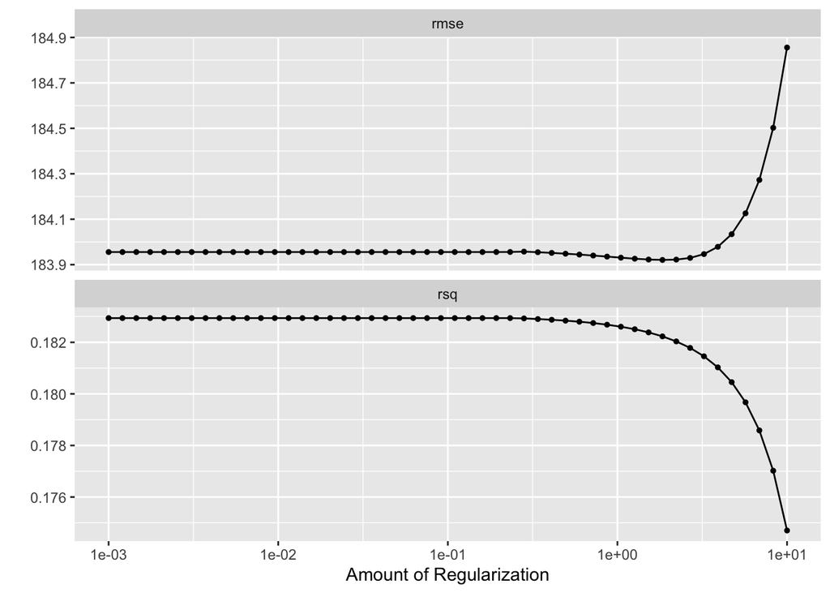

```r
autoplot(tune_res_lasso)
```

Looking at this plot, it clearly resembles that of the Ridge Regression model with very similar `rmse` and `rsq` values. Again, we can notice the really high rmse values and there are ranges of regularization that have no affect on the coeeficient estimates

```r
best_penalty_lasso <- select_best(tune_res, metric = "rsq")
best_penalty_lasso
```

```
## # A tibble: 1 × 2
##   penalty .config
##     <dbl> <chr>
## 1 0.00001 Preprocessor1_Model01
```

Then, I created a final fit for the Lassso model around the folded data set. Utilizing `augment()` I was able to use the test data to find the `estimate` value for this function which is about 0.203

```r
lasso_final <- finalize_workflow(lasso_workflow, best_penalty_lasso)

lasso_final_fit <- fit(lasso_final, data = ascents_train_numerical)

augment(lasso_final_fit, new_data = ascents_test_numerical) %>%
  rmse(truth = ascents, estimate = .pred)
```

```
## # A tibble: 1 × 3
##   .metric .estimator .estimate
##   <chr>   <chr>          <dbl>
## 1 rmse    standard        164.
```

```r
augment(lasso_final_fit, new_data = ascents_test_numerical) %>%
  rsq(truth = ascents, estimate = .pred)
```

```
## # A tibble: 1 × 3
##   .metric .estimator .estimate
##   <chr>   <chr>          <dbl>
## 1 rsq     standard       0.203
```

Thus, we can see that there is a negligible difference in accuracy between the Ridge Regression model and the Lasso Regression model.

## Random Forest Model

```r
random_spec <- rand_forest(mtry = tune(), min_n = tune(), trees = tune()) %>%
  set_engine("ranger", importance= "impurity") %>%
  set_mode("regression")
```

Next, I created a workflow and fit the numerical data to the model. Using the `tune-grid()`, I was able to resample using the folded data. This allowed me to then use `autoplot()` to acquire a visualization of the `trees` with the `rsq` and `rmse`.

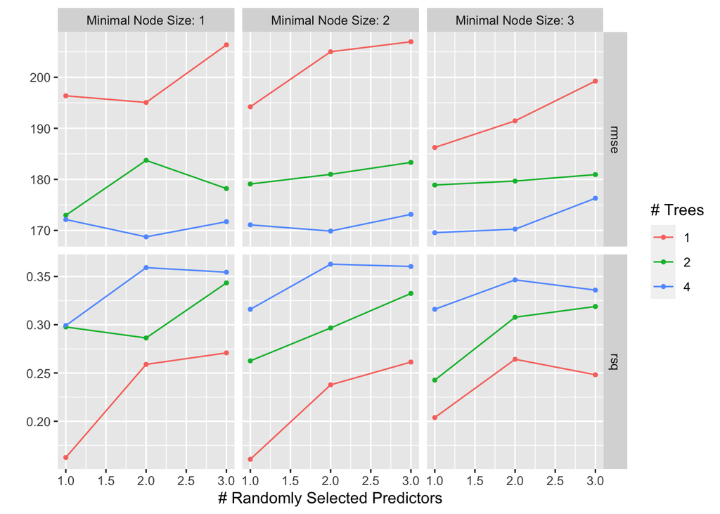

```r
random_wf <- workflow() %>%
  add_recipe(ascents_recipe_numerical) %>%
  add_model(random_spec)

random_grid <- grid_regular(min_n(range = c(1, 3)), mtry(range = c(1, 3)), trees(range = c(1, 4)), levels = 3)

tune_res_random = tune_grid(
  random_wf,
  resamples = ascents_fold_numerical,
  grid = random_grid
)


autoplot(tune_res_random)
```

Then, using `collect_metrics()` I was able to view the highest mean in this model.

```r
arrange(collect_metrics(tune_res_random), desc(mean))
```

```
## # A tibble: 54 × 9
##     mtry trees min_n .metric .estimator  mean     n std_err .config
##    <int> <int> <int> <chr>   <chr>      <dbl> <int>   <dbl> <chr>
##  1     3     1     2 rmse    standard    207.    50    6.31 Preprocessor1_Model…
##  2     3     1     1 rmse    standard    206.    50    7.72 Preprocessor1_Model…
##  3     2     1     2 rmse    standard    205.    50    6.64 Preprocessor1_Model…
##  4     3     1     3 rmse    standard    199.    50    6.74 Preprocessor1_Model…
##  5     1     1     1 rmse    standard    196.    50    5.85 Preprocessor1_Model…
##  6     2     1     1 rmse    standard    195.    50    5.37 Preprocessor1_Model…
##  7     1     1     2 rmse    standard    194.    50    6.35 Preprocessor1_Model…
##  8     2     1     3 rmse    standard    191.    50    5.62 Preprocessor1_Model…
##  9     1     1     3 rmse    standard    186.    50    5.93 Preprocessor1_Model…
## 10     2     2     1 rmse    standard    184.    50    4.94 Preprocessor1_Model…
## # … with 44 more rows
```

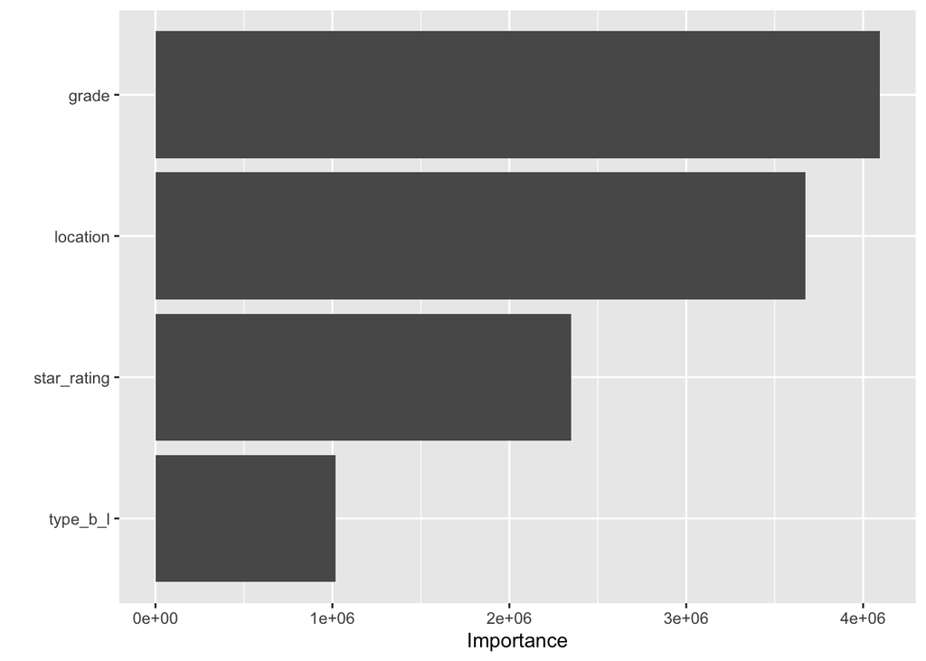

```r
random_spec_fit <- rand_forest(mtry = 2, trees = 4, min_n = 3) %>%
  set_engine("ranger", importance = "impurity") %>%
  set_mode("regression")

random_fit <- fit(random_spec_fit, ascents ~ .,
                   data = ascents_train_numerical)

vip(random_fit)
```

We can see that the most important variable in predicting the number of ascents is the `grade` of the climb. This is to be expected as the harder the route gets, the fewer people there are that do climb it. The second most important being location is also to be expected because as we saw in the EDA there are some `locations` that have far more ascents logged in general than other locations.

## Boosted Trees Model

The next model I will create is a Boosted Trees model. To set up this model, I used `boost_trees()` with the engine set to `xgboost` and the mode set to `regression`. Within the model I set the `trees`, `mtry`, and `min_n` equal to `tune()`, in order to tune the parameters.

```r
boost_model <- boost_tree(min_n = tune(), mtry = tune(), trees = tune()) %>%
  set_engine("xgboost") %>%
  set_mode("regression")

boost_wf <- workflow() %>%
  add_recipe(ascents_recipe_numerical) %>%
  add_model(boost_model)

boost_grid <- grid_regular(min_n(range = c(1, 2)), mtry(range = c(1, 7)), trees(range = c(1, 4)), levels = 6)

tune_res_boost <- tune_grid(
  boost_wf,
  resamples = ascents_fold_numerical,
  grid = boost_grid
)
```

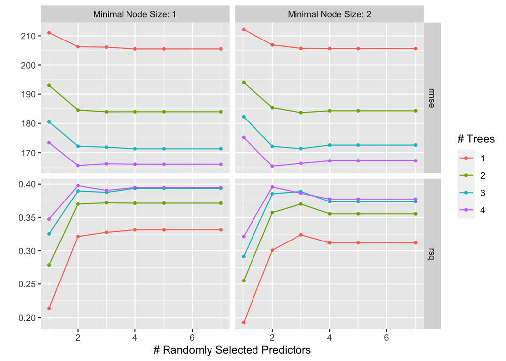

```r
autoplot(tune_res_boost)
```

```r
boosted_metrics <- arrange(collect_metrics(tune_res_boost), desc(mean))
boosted_metrics
```

```
## # A tibble: 96 × 9
##     mtry trees min_n .metric .estimator  mean     n std_err .config
##    <int> <int> <int> <chr>   <chr>      <dbl> <int>   <dbl> <chr>
##  1     1     1     2 rmse    standard    212.    50    7.05 Preprocessor1_Model…
##  2     1     1     1 rmse    standard    211.    50    6.95 Preprocessor1_Model…
##  3     2     1     2 rmse    standard    207.    50    6.73 Preprocessor1_Model…
##  4     2     1     1 rmse    standard    206.    50    6.93 Preprocessor1_Model…
##  5     3     1     1 rmse    standard    206.    50    6.81 Preprocessor1_Model…
##  6     3     1     2 rmse    standard    206.    50    6.89 Preprocessor1_Model…
##  7     4     1     2 rmse    standard    206.    50    6.75 Preprocessor1_Model…
##  8     5     1     2 rmse    standard    206.    50    6.75 Preprocessor1_Model…
##  9     7     1     2 rmse    standard    206.    50    6.75 Preprocessor1_Model…
## 10     4     1     1 rmse    standard    205.    50    6.79 Preprocessor1_Model…
## # … with 86 more rows
```

By creating a new function utilizing the parameters found in `collect_metrics()`, I am able to calculate the lowest `rmse` as well as view the variable importance plot.

```r
boost_spec <- boost_tree(trees = 4) %>%
  set_engine("xgboost") %>%
  set_mode("regression")

boost_fit <- fit(boost_spec, ascents ~ ., data = ascents_train_numerical)

augment(boost_fit, new_data = ascents_train_numerical) %>%
  rmse(truth = ascents, estimate = .pred)
```

```
## # A tibble: 1 × 3
##   .metric .estimator .estimate
##   <chr>   <chr>          <dbl>
## 1 rmse    standard        146.
```

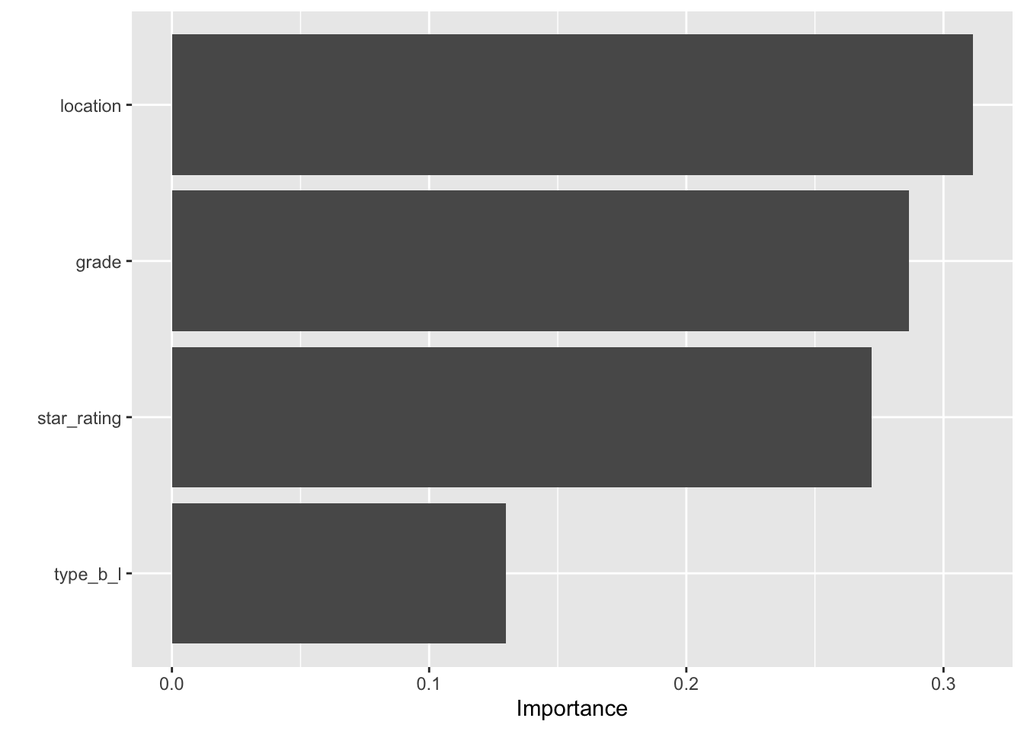

```r
vip(boost_fit)
```

It’s interesting to note that in the Boosted Trees model, the most important variable is location.

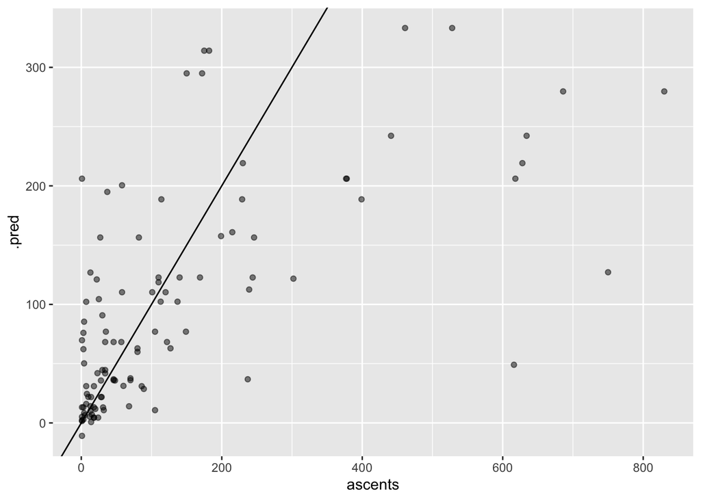

```r
augment(boost_fit, new_data = ascents_test_numerical) %>%
  ggplot(aes(ascents, .pred)) +
  geom_abline() +
  geom_point(alpha = 0.5)
```

## K-Nearest Neighbor Model

For the last model, I will be creating a K Nearest Neighbor Model. In order to set up this model, I used `nearest_neighbor()`, set `neighbors = tune()`, `mode = classfication`, and `set_engine = kknn`.

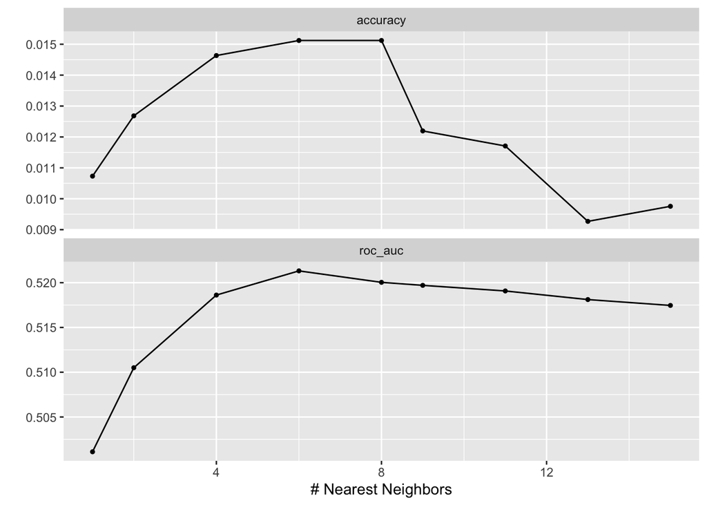

```r
k_nearest_model <- nearest_neighbor(
  neighbors = tune(),
  mode = "classification") %>%
  set_engine("kknn")

k_nearest_workflow <- workflow() %>%
  add_model(k_nearest_model) %>%
  add_recipe(ascents_recipe_factor)

k_nearest_params <- extract_parameter_set_dials(k_nearest_model)

k_grid <- grid_regular(k_nearest_params, levels = 9)

tune_res_k_nearest <- tune_grid(k_nearest_workflow, resamples = ascents_fold_factor, grid = k_grid)

# print an `autoplot()` of the result:
autoplot(tune_res_k_nearest)
```

```r
k_nearest_metrics <- arrange(collect_metrics(tune_res_k_nearest), mean(desc))
k_nearest_metrics
```

```
## # A tibble: 18 × 7
##    neighbors .metric  .estimator    mean     n std_err .config
##        <int> <chr>    <chr>        <dbl> <int>   <dbl> <chr>
##  1         1 accuracy multiclass 0.0107     50 0.00253 Preprocessor1_Model1
##  2         1 roc_auc  hand_till  0.501      50 0.00101 Preprocessor1_Model1
##  3         2 accuracy multiclass 0.0127     50 0.00234 Preprocessor1_Model2
##  4         2 roc_auc  hand_till  0.511      50 0.00192 Preprocessor1_Model2
##  5         4 accuracy multiclass 0.0146     50 0.00261 Preprocessor1_Model3
##  6         4 roc_auc  hand_till  0.519      50 0.00283 Preprocessor1_Model3
##  7         6 accuracy multiclass 0.0151     50 0.00278 Preprocessor1_Model4
##  8         6 roc_auc  hand_till  0.521      50 0.00290 Preprocessor1_Model4
##  9         8 accuracy multiclass 0.0151     50 0.00260 Preprocessor1_Model5
## 10         8 roc_auc  hand_till  0.520      50 0.00297 Preprocessor1_Model5
## 11         9 accuracy multiclass 0.0122     50 0.00234 Preprocessor1_Model6
## 12         9 roc_auc  hand_till  0.520      50 0.00301 Preprocessor1_Model6
## 13        11 accuracy multiclass 0.0117     50 0.00200 Preprocessor1_Model7
## 14        11 roc_auc  hand_till  0.519      50 0.00308 Preprocessor1_Model7
## 15        13 accuracy multiclass 0.00927    50 0.00219 Preprocessor1_Model8
## 16        13 roc_auc  hand_till  0.518      50 0.00330 Preprocessor1_Model8
## 17        15 accuracy multiclass 0.00976    50 0.00209 Preprocessor1_Model9
## 18        15 roc_auc  hand_till  0.517      50 0.00337 Preprocessor1_Model9
```

# Final Model Building

For the final model, I will be using the Boosted Forest model as it had the best `rsq` value out of all of the model.

```r
final_fit <- select_best(tune_res_boost, metric = "rsq")
boosted_tree_best <- finalize_workflow(boost_wf, final_fit)

boosted_train_fit <- fit(boosted_tree_best, data = ascents_train_numerical)

predict(boosted_train_fit, new_data = ascents_train_numerical, type = "numeric") %>%
  bind_cols(ascents_train_numerical %>% select(ascents)) %>%
  rsq(truth = ascents, estimate = .pred)
```

```
## # A tibble: 1 × 3
##   .metric .estimator .estimate
##   <chr>   <chr>          <dbl>
## 1 rsq     standard       0.521
```

After creating the final model, I am going to fit it to the test data to see how accurate it is.

```r
boosted_test <- fit(boosted_tree_best, data = ascents_test_numerical)

predict(boosted_test, new_data = ascents_test_numerical, type = "numeric") %>%
  bind_cols(ascents_test_numerical %>% select(ascents)) %>%
  rsq(truth = ascents, estimate = .pred)
```

```
## # A tibble: 1 × 3
##   .metric .estimator .estimate
##   <chr>   <chr>          <dbl>
## 1 rsq     standard       0.819
```

As we can see, the `rsq` value indicates a pretty good fit for our dataset.

## Testing the Final Model

Now, I am going to test a few values to see how it interprets the number of ascents. For this, I am going to set the `location = Rodellar` which is location 6 in my dataset, `grade = 8B` which corresponds to 14 in the numerical dataset, `type_b_l = 0` which corresponds to lead, and `star-rating = 4`.

```r
prediction <- data.frame(
  grade = 14,
  location = 6,
  type_b_l = 0,
  star_rating = 4
)

predict(boosted_train_fit, prediction)
```

```
## # A tibble: 1 × 1
##   .pred
##   <dbl>
## 1  139.
```

This is a pretty good estimate for the amount of ascents a climb with that data would acquire. It’s difficult to say what the correct answer was because there are multiple data points in this dataset that all have the same inputs. However, the climbs in the dataset with those characteristics had 241, 207, 157, 152, 127, and 121 in `location = Rodellar`. So, while this estimate is a little low given the number of ascents on climbs with that equivalent data, this isn’t very surprising because, as we saw in the EDA, `Rodellar` has by far the most ascents in general. Thus it’s not very surprising that it underestimated the number of ‘ascents’ for that ‘location’.

Now, I am going to test a prediction in a different `location`. This time, I am going to set `location = Ceuse` and keep the other variables the same as the prediction before.

```r
prediction <- data.frame(
  grade = 14,
  location = 2,
  type_b_l = 0,
  star_rating = 4
)

predict(boosted_train_fit, prediction)
```

```
## # A tibble: 1 × 1
##   .pred
##   <dbl>
## 1  116.
```

Now, in this prediction, I am going yo change the `type` of climbing to Bouldering and see how the model responds. For this I am going to set `grade = 7A` (which corresponds to 6), `location = Buttermilks` (corresponds to 1), `type = bouldering` (corresponds to 1), and `star rating = 3`.

```r
prediction <- data.frame(
  grade = 6,
  location = 1,
  type_b_l = 1,
  star_rating = 3
)

predict(boosted_train_fit, prediction)
```

```
## # A tibble: 1 × 1
##   .pred
##   <dbl>
## 1  183.
```

# Conclusion

For this project, I used data collected from *[8a.nu](https://www.8a.nu/crags/sportclimbing)*, a platform for climbers to log their ascents and track their progress. This website has over 6 million logged ascents with over 100,000 members. Originally, I was planning on using all of the data on this platform, but after reaching out to the creator and their team, they said it would be too difficult and costly for them to acquire data across the entire website. However, I was able to acquire data from six of the most popular areas.

As I outlined in the introduction, there are two main disciplines (Lead and Bouldering) which I used as one of the predictors in my model. In the Exploratory Data Analysis, we were able to see that certain locations are primarily Bouldering or Lead, not both. This was useful in the model building and ultimately predicting the number of ascents. We were also able to see that there was an inverse relationship between grade and the number of ascents. This was to be expected. It was also interesting to note how `grade` and `star rating` had a positive correlation. I think this is because there are far fewer harder climbs in general. Since so many more people can establish easier grades for the first time, the field gets over saturated with climbs at lower `grades` and lower `star rating`.

After doing the exploratory analysis, I did the model building and was able to see that the best model for our prediction was the Boosted Trees model. In this section, we were able to see that the most important variable in predicting the number of ascents, was the ‘location’ which I did not expect, but it does make sense as some of the locations have far more ascents overall than others.

If I were to do this project again, I would try to include more predictors such as time to get to the location and when the climb was first established.